# HMM parallelization

The goal here is to optimize the speed of OneMap HMM algorithm to distance estimation. For this, we split a ordered sequence in groups according to the number of cores available to the analyses. The groups have a overlap of markers in their edges, to be possible the later joint of them. Here we use this overlap markers also to compare the estimated genetic distance between groups and see how the process can affect the maps distances.

Tests:

- **Scenario 1**: 28 markers of each one of the 18 possible types, without missing data
- **Scenario 2**: 168 markers of D1.10, D2.15 and B3.7 types, without missing data
- **Scenario 3**: 28 markers of each one of the 18 possible types, 25% of missing data
- **Scenario 4**: 168 markers of D1.10, D2.15 and B3.7 types, 25% of missing data

Measures:

- Total size
- Recombination fraction difference between overlap markers
- Time to run

Other test applied was increase the tol value of the HMM. All scenarios were repeted with tol value of $10^{-3}$ (the default value is $10^{-5}$).

## Packages

```r
library(parallel)
library(onemap) # private version
library(tidyverse)
```

## Functions

```r
runcomp <- function(n.marker, mk.types, n.types, miss.perc,tol=10E-5){
  n.fam <- 5
  int.tot.size <- par.tot.size <- int.time <- par.time <- int.cms <- par.cms <-  diff2 <- vector()
  batch.tot.size  <- batch.time <- batch.cms <- vector()
  for(w in 1:n.fam){
    run_pedsim(chromosome = c("Chr1"), n.marker = n.marker, tot.size.cm = c(100), centromere = c(50),
               n.ind = 200, mk.types = mk.types,
               n.types = n.types, pop = "F1", path.pedsim = "~/Programs/PedigreeSim/",
               name.mapfile = "mapfile.map", name.founderfile="founderfile.gen",
               name.chromfile="sim.chrom", name.parfile="sim.par",
               name.out="sim_out")

    pedsim2raw(cross="outcross", genofile = "sim_out_genotypes.dat", parent1 = "P1", parent2 = "P2", out.file = "sim_out.example1.raw", miss.perc = miss.perc)

    df <- read_onemap("sim_out.example1.raw")

    twopts <- rf_2pts(df)

    seq1 <- make_seq(twopts, "all")

    batch_size <- pick_batch_sizes(input.seq = seq1,
                                   size = 80,
                                   overlap = 30,
                                   around = 10)

    batch.time <- rbind(batch.time, system.time(batch.map <- map_overlapping_batches(input.seq = seq1,
                                         size = batch_size,
                                         phase_cores = 4,
                                         overlap = 30, rm_unlinked = T)))

    batch.cms <- rbind(batch.cms, cumsum(c(0, haldane(batch.map[[1]]$seq.rf))))
    batch.tot.size <- c(batch.tot.size, batch.cms[length(batch.cms)])

    int.time <- rbind(int.time, system.time(int.map <- map(seq1, tol=tol)))
    int.cms <- rbind(int.cms, cumsum(c(0,haldane(int.map$seq.rf))))
    int.tot.size <- c(int.tot.size, int.cms[length(int.cms)])

    par.time <- rbind(par.time, system.time(map2 <- parmap(input.seq = seq1, cores = 6, overlap = 5, tol=tol)))

    diff2 <- rbind(diff2, map2[[1]])

    par.map <- map2[[2]]
    par.cms <- rbind(par.cms, cumsum(c(0,haldane(par.map$seq.rf))))
    par.tot.size <- c(par.tot.size, par.cms[length(par.cms)])
  }
  result <- list(diff2, int.tot.size, par.tot.size, batch.tot.size,
                 int.time, par.time, batch.time, int.cms, par.cms, batch.cms)
  names(result) <- c("diff", "int.tot.size", "par.tot.size", "batch.tot.size",
                     "int.time", "par.time", "batch.time", "int.cms", "par.cms", "batch.cms")

  return(result)
}
```

# Running each scenario

- scenario (1)

```r
cen1 <- runcomp(n.marker = 504,
                mk.types = c("A1", "A2", "A3", "A4", "B1.5", "B2.6", "B3.7",
                             "C.8", "D1.9", "D1.10", "D1.11", "D1.12", "D1.13",
                             "D2.14", "D2.15", "D2.16", "D2.17", "D2.18"),
                n.types = rep(28,18),
                miss.perc = 0)
```

- scenario (2)

```r
cen2 <- runcomp(n.marker = 504,
                mk.types = c("B3.7","D1.10", "D2.15"),
                n.types = rep(168,3),
                miss.perc = 0)
```

- scenario (3)

```r
cen3 <- runcomp(n.marker = 504,
                mk.types = c("A1", "A2", "A3", "A4", "B1.5", "B2.6", "B3.7",
                             "C.8", "D1.9", "D1.10", "D1.11", "D1.12", "D1.13",
                             "D2.14", "D2.15", "D2.16", "D2.17", "D2.18"),
                n.types = rep(28,18),
                miss.perc = 25)
```

- scenario (4)

```r
cen4 <- runcomp(n.marker = 504,
                mk.types = c("B3.7","D1.10", "D2.15"),
                n.types = rep(168,3),
                miss.perc = 25)
```

- scenario (1) tol

```r
cen1.tol <- runcomp(n.marker = 504,
                    mk.types = c("A1", "A2", "A3", "A4", "B1.5", "B2.6", "B3.7",
                                 "C.8", "D1.9", "D1.10", "D1.11", "D1.12", "D1.13",
                                 "D2.14", "D2.15", "D2.16", "D2.17", "D2.18"),
                    n.types = rep(28,18),
                    miss.perc = 0, tol=10E-4)
```

- scenario (2) tol

```r
cen2.tol <- runcomp(n.marker = 504,
                    mk.types = c("B3.7","D1.10", "D2.15"),
                    n.types = rep(168,3),
                    miss.perc = 0, tol=10E-4)
```

- Scenario (3) tol

```r
cen3.tol <- runcomp(n.marker = 504,
                    mk.types = c("A1", "A2", "A3", "A4", "B1.5", "B2.6", "B3.7",
                                 "C.8", "D1.9", "D1.10", "D1.11", "D1.12", "D1.13",
                                 "D2.14", "D2.15", "D2.16", "D2.17", "D2.18"),
                    n.types = rep(28,18),
                    miss.perc = 25, tol=10E-4)
```

- Scenario (4) tol

```r
cen4.tol <- runcomp(n.marker = 504,
                    mk.types = c("B3.7","D1.10", "D2.15"),
                    n.types = rep(168,3),
                    miss.perc = 25, tol=10E-4)

save.image("results.RData")
```

# Results

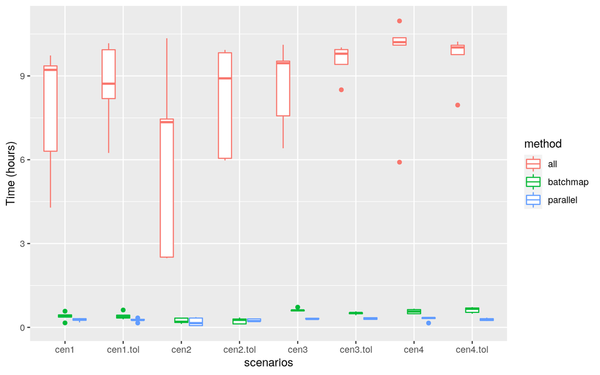

```r
load("results.RData")

tot.size.cm <- 100
n.marker <- 504
int <- tot.size.cm/n.marker
pos <- seq(from=0, to=tot.size.cm, by=int)

tot.cen <- list(cen1, cen1.tol, cen2.tol, cen2, cen3, cen3.tol, cen4, cen4.tol)
names(tot.cen) <- c("cen1", "cen1.tol", "cen2", "cen2.tol", "cen3", "cen3.tol", "cen4",
                       "cen4.tol")

df_diff <- df_tot_size <- df_times <- df_sizes <-  vector()
for(i in 1:length(tot.cen)){
  # Diff
  temp.df <- cbind(paste0("simu",1:length(tot.cen[[i]][[2]])), sqrt(tot.cen[[i]][[1]]^2))
  colnames(temp.df) <- c("simu", paste0("Overlap", 1:dim(tot.cen[[i]][[1]])[2]))
  diff <- gather(data.frame(temp.df), key, value, -simu)
  df_diff <- rbind(df_diff, data.frame(scen= names(tot.cen)[i], diff))

  # tot.size
  temp.df <- data.frame(tot.cen[[i]][c(2:3,8)]) # change here
  temp.df <- cbind(simu = paste0("simu", 1:length(tot.cen[[i]][[2]])), temp.df)
  colnames(temp.df) <- c("simu", "all", "parmap", "batchmap")
  df_tot_size <- rbind(df_tot_size, data.frame(scen= names(tot.cen)[i],temp.df))

  # time
  temp.df <- data.frame(simu = paste0("simu", 1:length(tot.cen[[i]][[2]])),
                        int.time= tot.cen[[i]][[4]][,3],
                        par.time = tot.cen[[i]][[5]][,3],
                        batch.time = tot.cen[[i]][[9]][,3]) # change here
  colnames(temp.df) <- c("simu", "all", "parallel", "batchmap")
  df_times <- rbind(df_times, data.frame(scen= names(tot.cen)[i],temp.df))


  # cMs

  temp.int <- t(apply(tot.cen[[i]][[6]],1, function(x) sqrt((x-pos[-1])^2)))
  temp.par <- t(apply(tot.cen[[i]][[7]],1, function(x) sqrt((x-pos[-1])^2)))
  temp.batch <- t(apply(tot.cen[[i]][[10]],1, function(x) sqrt((x-pos[-1])^2)))

  colnames(temp.int) <- paste0("MK",1:dim(temp.int)[2])
  colnames(temp.par) <- paste0("MK",1:dim(temp.par)[2])
  colnames(temp.batch) <- paste0("MK",1:dim(temp.batch)[2])

  temp.int <- data.frame(simu = paste0("simu", 1:length(tot.cen[[i]][[2]])),
                         temp.int)
  temp.int <- gather(temp.int, key, value,-simu)
  temp.par <- data.frame(simu = paste0("simu", 1:length(tot.cen[[i]][[2]])),
                         temp.par)
  temp.par <- gather(temp.par, key, value,-simu)
  temp.batch <- data.frame(simu = paste0("simu", 1:length(tot.cen[[i]][[2]])),
                         temp.batch)
  temp.batch <- gather(temp.batch, key, value,-simu)

  temp.df <- merge(temp.int, temp.par, by = c("simu", "key"))
  temp.df <- merge(temp.df, temp.batch, by=c("simu", "key"))
  colnames(temp.df) <- c("simu", "mk", "all", "parmap", "batchmap")
  df_sizes <- rbind(df_sizes, data.frame(scen = names(tot.cen)[i],temp.df))
}

# Time

df_times %>% gather(key, value, -simu, -scen) %>%
  ggplot(aes(x=scen, y=value/3600, color=key)) +
  geom_boxplot() +
  xlab("scenarios") +
  ylab("Time (hours)") +
  scale_color_discrete(name="method")
```

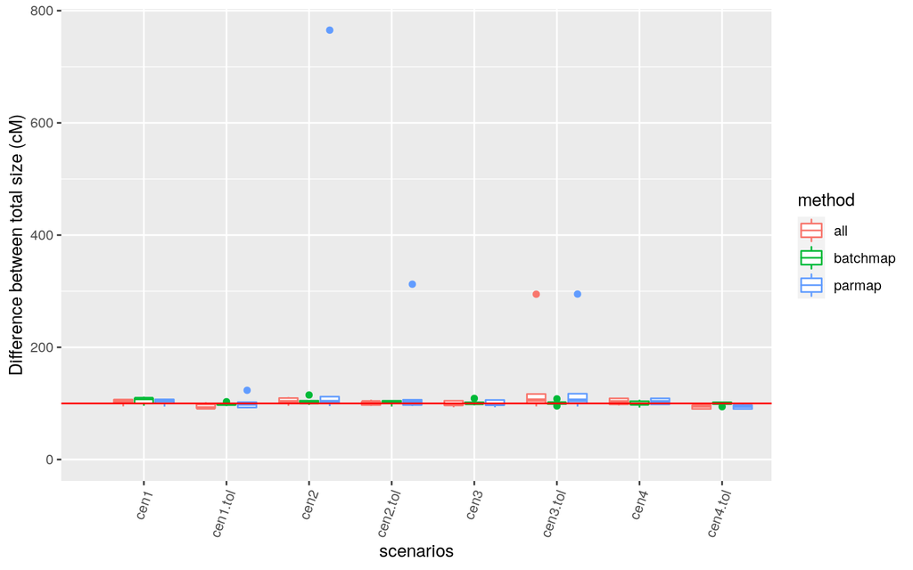

```r
# Total sizes
df_tot_size %>% gather(key, value, -scen, -simu) %>%
  ggplot(aes(x=scen, y=value, color=key)) +
  geom_boxplot() +
  geom_hline(yintercept=100, color = "red") +
  theme(axis.text.x = element_text(angle = 70, hjust = 1)) +
  xlab("scenarios") +
  ylab("Difference between total size (cM)") +
  scale_color_discrete(name="method") +
  expand_limits(x = 0, y = 0)
```

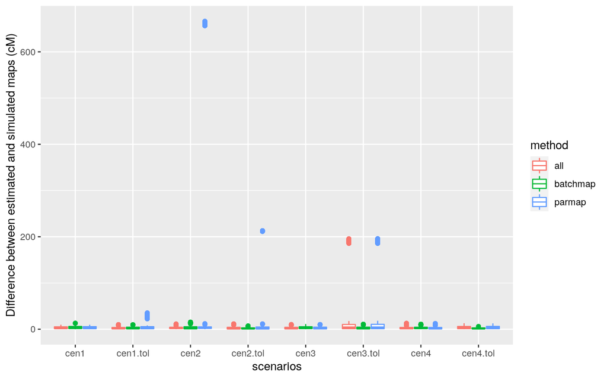

```r
# Size difference of the intervals between the markers of the generated map and the simulated map. PS: the best result would be if all the points are close to the x axis (difference 0)

df_sizes %>% gather(key, value, -scen, -simu, -mk) %>%
  ggplot(aes(x=scen, y=value, color=key)) +
  geom_boxplot() +
  scale_color_discrete(name="method") +
  xlab("scenarios") +
  ylab("Difference between estimated and simulated maps (cM)")
```

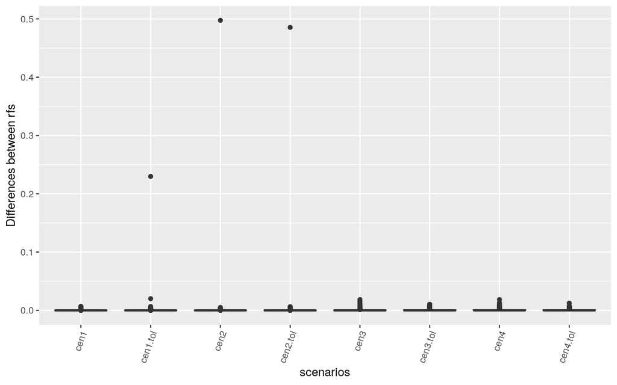

```r
# Measure the difference of recombination fraction between overlap markers, in other words, the markers which are in the end of the last group and at the beggining of the next group.

df_diff %>% ggplot(aes(x = scen, y = as.numeric(value))) +
  geom_boxplot() +
  theme(axis.text.x = element_text(angle = 70, hjust = 1)) +
  xlab("scenarios") +
  ylab("Differences between rfs")
```